# Strategic Market Analysis

Karen, Samuel, Laurence

February 8, 2019

## Introduction

As of the latest 2015 data, AB InBev enjoys a 45.8% Share of the US beer market. While the merger with InBev has made Anheuser-Busch the largest brewer in America, when aggregate data is considered AB InBev has in fact seen a total reduction of 1.4% in its share of the US beer market when compared to 2014 data, this despite the fact that worldwide, AB InBev has seen a steady growth in market share. One factor for this may be the growing micro brew movement and the influx of craft beers into the market. AB InBev’s market strategy has been and continues to be the marketing and support of its core Brands and segment growth through acquisition of established brands. However, an analysis of market competition seems to indicates that the micro brew movement has grown from a novelty product to a serious brand competitor. This analysis will explore AB InBev’s emerging competition by analyzing the breweries and beers currently competing for US consumers.

## The Data

Data was derived from a nationwide dataset of 558 US breweries and a matching dataset of 2,410 US craft beers. We analyzed the data and compared it to state geographic data to determine the distribution of the breweries by state. We then analyzed the alcohol by volume (ABV) and international bitterness units (IBU) of the sampled beers to identify trends, characteristics, correlations.

```r
#Read in the beers.csv and set to data frame
Beers <- read.csv("C:/git/DDSCase1/CaseStudy1/Beers.csv", header = TRUE, sep = ",")

#Read in the Breweries.csv and set to data frame
Breweries <- read.csv("C:/git/DDSCase1/CaseStudy1/Breweries.csv", header = TRUE, sep = ",")

#Read in the states.csv and set to data frame
States <- read.csv("C:/git/DDSCase1/CaseStudy1/states.csv", header = TRUE, sep = ",")
```

## Analysis Tools for R-Studio

To conduct the research we used R-studio as our primary statistical analysis software and loaded the following statistical packages:

library(dplyr)  
library(knitr)  
library(rvest)  
library(ggplot2)  
library(psych)  
library(maps)  
library(plyr)

## From Alaska to Wyoming A Revolution is Brewing

Nationwide there has been a tremendous increase in the number of microbreweries that have entered the market over the last five years. According to data from the Brewer’s Association the number of microbreweries in the US jumped from 620 in 2010 to 2,626 in 2015.

###### *https://www.brewersassociation.org/statistics/number-of-breweries/

```r
#reduce data set to Brewery, State, and Beer
beers <- BeerData[c(1,3,5)]

#pull and filter sample beers and display from head
Alaska <- head(beers,10)
P1 <- Alaska[2:7, ]

#pull and filter sample beers and display from tail
Wyoming <- tail(beers)
P2 <- Wyoming[1:6, ]

knitr::kable(list(P1, P2), row.names = FALSE)
```

| Brewery | State | Style |
| --- | --- | --- |
| King Street Brewing Company | AK | American Blonde Ale |
| King Street Brewing Company | AK | Czech Pilsener |
| King Street Brewing Company | AK | American IPA |
| King Street Brewing Company | AK | Hefeweizen |
| Midnight Sun Brewing Company | AK | American IPA |
| Midnight Sun Brewing Company | AK | American Brown Ale |

| Brewery | State | Style |
| --- | --- | --- |
| The Black Tooth Brewing Company | WY | American Pale Wheat Ale |
| The Black Tooth Brewing Company | WY | English Brown Ale |
| The Black Tooth Brewing Company | WY | American IPA |
| The Black Tooth Brewing Company | WY | American Amber / Red Ale |
| Wind River Brewing Company | WY | American Blonde Ale |
| Wind River Brewing Company | WY | American Pale Ale (APA) |

## Data Driven Brewing

Thoug small, most of the breweries are making complex beers for an ever growing market of consumers that want to know more about beer. All 2,410 beers in the data set had a specified style and type, 97% of the beers had a specified ABV, and 58% of the beers had a specified IBU.

```r
colSums(!is.na(BeerData[4:7]))
```

```
##  Beer Style   ABV   IBU
##  2410  2410  2348  1405
```

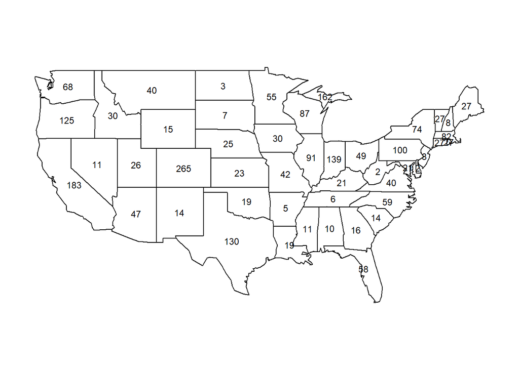

[output not shown]

[output not shown]

[output not shown]

[figure not shown]

```r
#Plot of Breweries per State
library(ggplot2)
b1 <- ggplot(BreweryState, aes(x=reorder(BreweryState$State,-BreweryState$freq), y=BreweryState$freq, fill=BreweryState$State)) +

geom_bar(stat="identity") + labs(title ="Breweries in States", x= "States", y="Number of Breweries", fill="States") + theme(text = element_text(size=7),axis.text.x = element_text(angle=90, hjust=1))
b1
```

# A Look into ABV and IBU

The median alcohol content and international bitterness units were calculated for each state and are shown in the tables and barplots below.

```r
#Compute the median alcohol content and international bitterness unit for each state. Plot a bar chart to compare.
library(psych)
#library(kableExtra)
ABV_St <- describeBy(dataset_merge$ABV, dataset_merge$State, mat=T)
colnames(ABV_St)[colnames(ABV_St)=="group1"] <- "State"
IBU_St <- describeBy(dataset_merge$IBU, dataset_merge$State, mat=T)
colnames(IBU_St)[colnames(IBU_St)=="group1"] <- "State"
head(IBU_St)
```

```
##     item State vars   n     mean       sd median  trimmed     mad min max
## X11    1    AK    1  17 40.88235 23.32617   46.0 40.93333 35.5824  10  71
## X12    2    AL    1   9 51.22222 24.68186   43.0 51.22222 19.2738  25 103
## X13    3    AR    1   1 39.00000       NA   39.0 39.00000  0.0000  39  39
## X14    4    AZ    1  24 35.20833 25.70058   20.5 31.85000  8.1543   9  99
## X15    5    CA    1 135 46.28148 27.43722   42.0 44.71560 34.0998   4 115
## X16    6    CO    1 146 47.43151 26.06171   40.0 45.62712 32.6172   9 104
##     range        skew    kurtosis       se
## X11    61 -0.04739132 -1.78830022 5.657428
## X12    78  0.83017391 -0.56708694 8.227288
## X13     0          NA          NA       NA
## X14    90  1.12322454 -0.01202231 5.246109
## X15   111  0.39836627 -0.97932580 2.361419
## X16    95  0.42558396 -1.02740400 2.156882
```

```r
ABV_St[,c(2,7)] %>%
  kable() %>%
  kable_styling()
```

|  | State | median |
| --- | --- | --- |
| X11 | AK | 0.0560 |
| X12 | AL | 0.0600 |
| X13 | AR | 0.0520 |
| X14 | AZ | 0.0550 |
| X15 | CA | 0.0580 |
| X16 | CO | 0.0605 |
| X17 | CT | 0.0600 |
| X18 | DC | 0.0625 |
| X19 | DE | 0.0550 |
| X110 | FL | 0.0570 |
| X111 | GA | 0.0550 |
| X112 | HI | 0.0540 |
| X113 | IA | 0.0555 |
| X114 | ID | 0.0565 |
| X115 | IL | 0.0580 |
| X116 | IN | 0.0580 |
| X117 | KS | 0.0500 |
| X118 | KY | 0.0625 |
| X119 | LA | 0.0520 |
| X120 | MA | 0.0540 |
| X121 | MD | 0.0580 |
| X122 | ME | 0.0510 |
| X123 | MI | 0.0620 |
| X124 | MN | 0.0560 |
| X125 | MO | 0.0520 |
| X126 | MS | 0.0580 |
| X127 | MT | 0.0550 |
| X128 | NC | 0.0570 |
| X129 | ND | 0.0500 |
| X130 | NE | 0.0560 |
| X131 | NH | 0.0550 |
| X132 | NJ | 0.0460 |
| X133 | NM | 0.0620 |
| X134 | NV | 0.0600 |
| X135 | NY | 0.0550 |
| X136 | OH | 0.0580 |
| X137 | OK | 0.0600 |
| X138 | OR | 0.0560 |
| X139 | PA | 0.0570 |
| X140 | RI | 0.0550 |
| X141 | SC | 0.0550 |
| X142 | SD | 0.0600 |
| X143 | TN | 0.0570 |
| X144 | TX | 0.0550 |
| X145 | UT | 0.0400 |
| X146 | VA | 0.0565 |
| X147 | VT | 0.0550 |
| X148 | WA | 0.0555 |
| X149 | WI | 0.0520 |
| X150 | WV | 0.0620 |
| X151 | WY | 0.0500 |

```r
IBU_St[,c(2,7)] %>%
  kable() %>%
  kable_styling()
```

|  | State | median |
| --- | --- | --- |
| X11 | AK | 46.0 |
| X12 | AL | 43.0 |
| X13 | AR | 39.0 |
| X14 | AZ | 20.5 |
| X15 | CA | 42.0 |
| X16 | CO | 40.0 |
| X17 | CT | 29.0 |
| X18 | DC | 47.5 |
| X19 | DE | 52.0 |
| X110 | FL | 55.0 |
| X111 | GA | 55.0 |
| X112 | HI | 22.5 |
| X113 | IA | 26.0 |
| X114 | ID | 39.0 |
| X115 | IL | 30.0 |
| X116 | IN | 33.0 |
| X117 | KS | 20.0 |
| X118 | KY | 31.5 |
| X119 | LA | 31.5 |
| X120 | MA | 35.0 |
| X121 | MD | 29.0 |
| X122 | ME | 61.0 |
| X123 | MI | 35.0 |
| X124 | MN | 44.5 |
| X125 | MO | 24.0 |
| X126 | MS | 45.0 |
| X127 | MT | 40.0 |
| X128 | NC | 33.5 |
| X129 | ND | 32.0 |
| X130 | NE | 35.0 |
| X131 | NH | 48.5 |
| X132 | NJ | 34.5 |
| X133 | NM | 51.0 |
| X134 | NV | 41.0 |
| X135 | NY | 47.0 |
| X136 | OH | 40.0 |
| X137 | OK | 35.0 |
| X138 | OR | 40.0 |
| X139 | PA | 30.0 |
| X140 | RI | 24.0 |
| X141 | SC | 30.0 |
| X142 | SD | NA |
| X143 | TN | 37.0 |
| X144 | TX | 33.0 |
| X145 | UT | 34.0 |
| X146 | VA | 42.0 |
| X147 | VT | 30.0 |
| X148 | WA | 38.0 |
| X149 | WI | 19.0 |
| X150 | WV | 57.5 |
| X151 | WY | 21.0 |

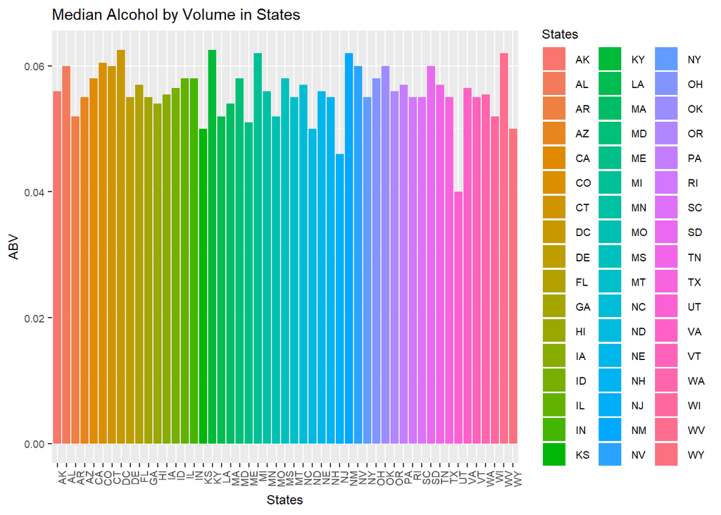

```r
#bar plot of Median Alcohol by volumne
ABV_plot <- ggplot(ABV_St, aes(x=ABV_St$State, y=ABV_St$median, fill=ABV_St$State)) +
  geom_bar(stat="identity") + labs(title ="Median Alcohol by Volume in States", x= "States", y="ABV", fill="States") + theme(text = element_text(size=9),axis.text.x = element_text(angle=90, hjust=1))
ABV_plot
```

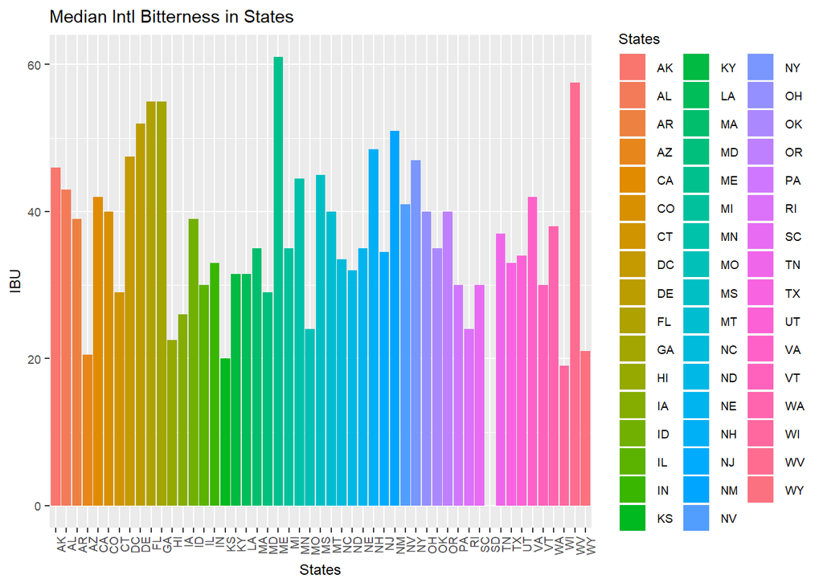

```r
#bar plot of Median IBU in states
IBU_plot <- ggplot(IBU_St, aes(x=IBU_St$State, y=IBU_St$median, fill=IBU_St$State)) +
  geom_bar(stat="identity") + labs(title ="Median Intl Bitterness in States", x= "States", y="IBU", fill="States") + theme(text = element_text(size=9),axis.text.x = element_text(angle=90, hjust=1))
IBU_plot
```

As shown graphically, Kentucky (KY) and Washington D.C. (DC) have breweries with the highest alcohol content (ABV) based on median values.

Comparing the medians of IBU for each state, the most bitter beers are found in Maine.

Alcohol by Volume across all breweries ranges from 0.001 to 0.1280. The average ABV is 0.05977 which is slightly higher than the median of 0.056. This means that the average ABV level is pulled higher by some beers with higher alcohol content, but the concentration of ABV levels is close to being evenly scattered around the average. The first quartile is 0.05 and the third quartile is 0.067.

```r
#Kentucky KY and DC show to be hightes  median ABV
summary(dataset_merge$ABV)
```

```
##    Min. 1st Qu.  Median    Mean 3rd Qu.    Max.    NA's
## 0.00100 0.05000 0.05600 0.05977 0.06700 0.12800      62
```

The international bitterness units range from 4 to 138 across the beers. In this distribution there are more beers are concentrated towards the lower end of IBU levels. There are some very bitter beers that skew the average IBU level (42.71) to be higher than the median IBU value (35). The first quartile IBU is 21 and the third quartile is 64.

```r
#max IBU shown to be Maine (ME)
summary(dataset_merge$IBU)
```

```
##    Min. 1st Qu.  Median    Mean 3rd Qu.    Max.    NA's
##    4.00   21.00   35.00   42.71   64.00  138.00    1005
```

```r
library(ggplot2)
```

There is a positive linear trend between IBU and ABV, meaning as alchol content increases, bitterness tends to increase as well. However, due to the fanning shape of the scatterplot, it appears that beers with lower alcohol content appear to have more similar bitterness levels than those with higher alchol. At higher ABV, there is more variation in bitterness levels. Beers can either have a low bitterness level or high level at the same alcohol content level, but on average, the bitterness tends to be higher than beers with lower ABV.

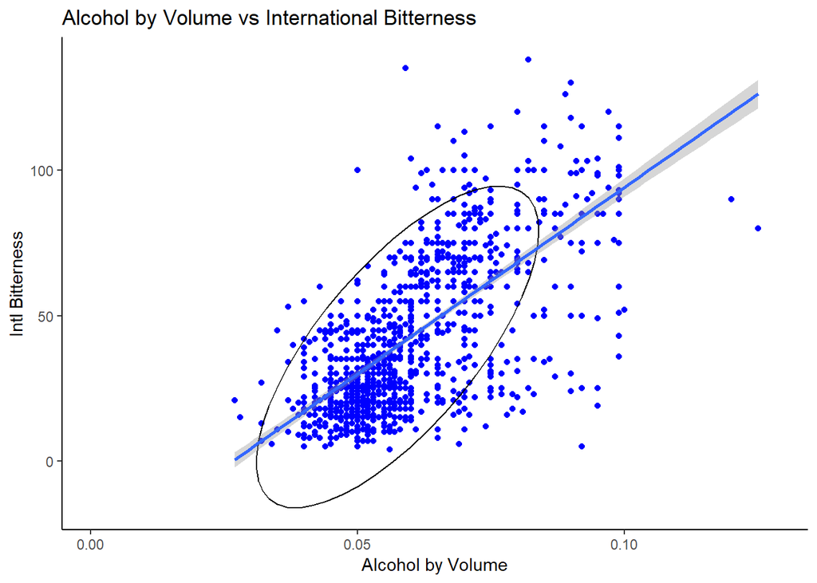

```r
scatter2<- ggplot(dataset_merge[,-1], aes(x=dataset_merge$ABV, y=dataset_merge$IBU))+geom_point(color="blue")+labs(title="Alcohol by Volume vs International Bitterness",x="Alcohol by Volume", y = "Intl Bitterness")+  theme_classic()+ stat_ellipse() + geom_smooth(method=lm)
scatter2
```

This graph shows the both the median ABV and IBU values for each state. Particular states of interest are Utah and New Jersey, who have low median ABV levels compared to the clustered range of the other states. Likewise, Florida, Georgia, Maine, and West Virginia differ greatly from the other states and tend to have beers with higher bitterness levels.

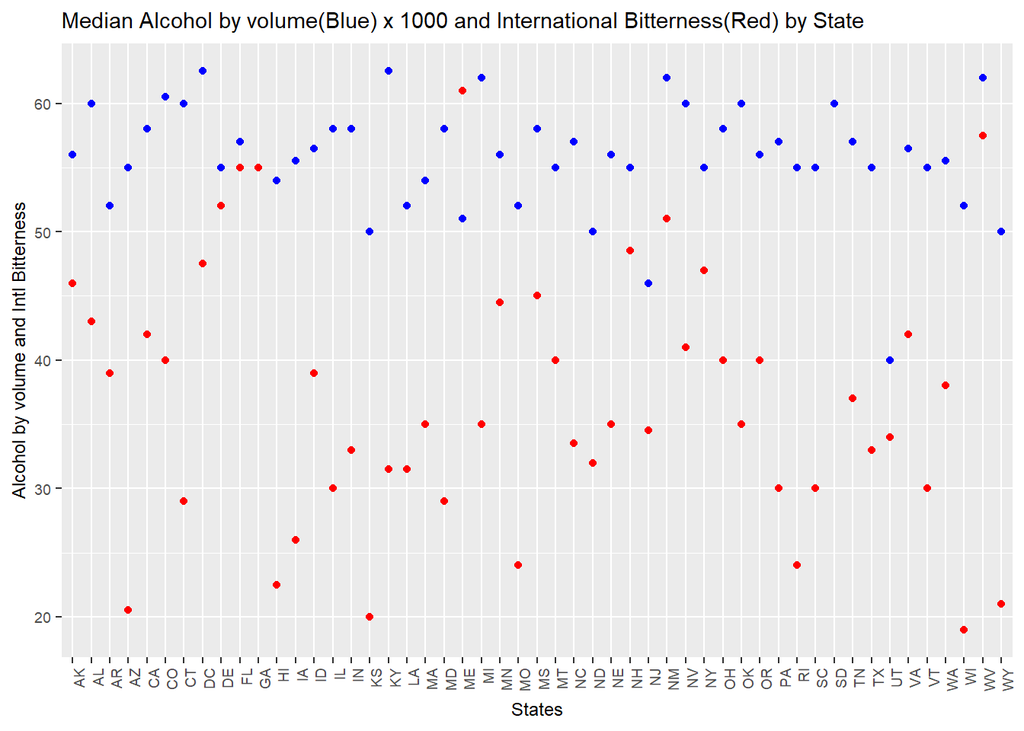

```r
# point bplot by state
med_plot_by_state <- ggplot(ABV_IBU_merge, aes(x = ABV_IBU_merge$group1)) +
  geom_point(aes(y = ABV_IBU_merge$median.x *1000), colour="blue") +
  geom_point(aes(y = ABV_IBU_merge$median.y), colour = "red") +
  ylab(label="Alcohol by volume and Intl Bitterness") +
  xlab("States") + theme(text = element_text(size=9),axis.text.x = element_text(angle=90, hjust=1)) + ggtitle("Median Alcohol by volume(Blue) x 1000 and International Bitterness(Red) by State")
med_plot_by_state
```

```r
sample<-sample.int(2410,250)
```

For readability, a random sample of 250 beers were selected to invesigate the variance in differences between IBU and ABV. The variance in these differences are pretty high, since all the line segments are not the same length. This further supports the idea that bitterness levels are highly variable, and are only partially explained by alcohol content.

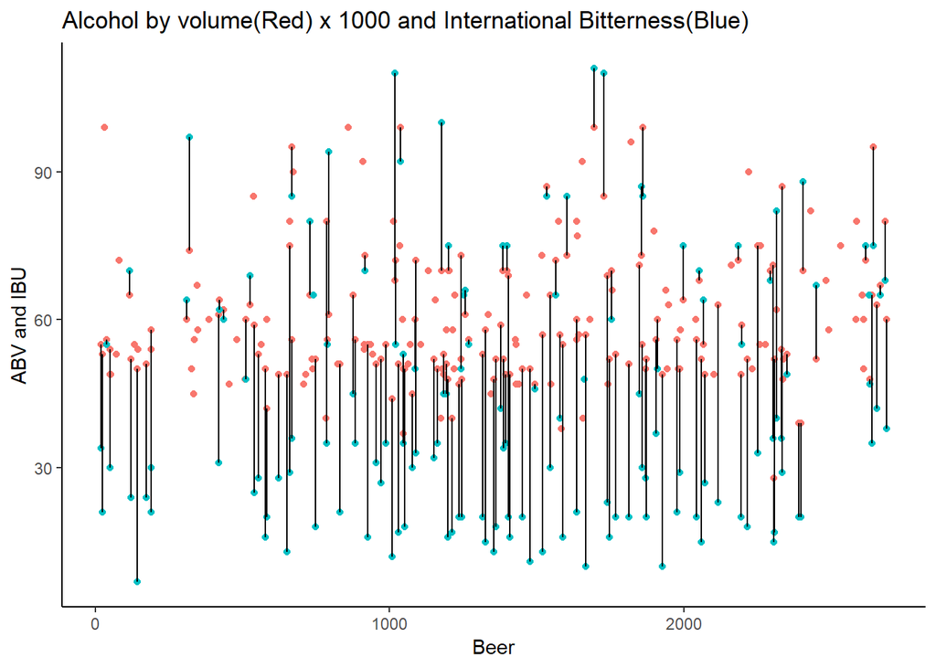

```r
combined<-ggplot(dataset_merge[sample,-1], aes(x=Beer_ID))+
  geom_point(aes(y=dataset_merge[sample,7]*1000, colour="blue"), show.legend = FALSE)+
  geom_point(aes(y=dataset_merge[sample,8], colour="red"), show.legend = FALSE)+
  geom_segment(aes(x=dataset_merge[sample,6], y=dataset_merge[sample,7]*1000,xend=dataset_merge[sample,6], yend=dataset_merge[sample,8]))+ ylab(label="ABV and IBU")+
  xlab("Beer")+theme(text=element_text(size=9),axis.text.x = element_text(angle=90, hjust=1)) + ggtitle("Alcohol by volume(Red) x 1000 and International Bitterness(Blue)")+theme_classic()
combined
```

# Recommendations

Competition is growing for AB InBev. Competitors have beers with a wide variety of IBU levels, and these levels also vary by state. This suggests that tastes differ in different markets, and also that tastes are expanding from just a singular style of beer. To compete, InBev should diversify their beer offerings, even regionally. Most beers tend to have similar alcohol content levels, although some variation in ABV is another dimension that can add to InBev’s beer profile. AB InBev should strategically position themselves to meet the expanding consumer demand.